# An analysis of the Iris dataset

First of all, it is fair enough to look into the dataset and get to know its nature. Here, I will be looking into the dimensions and into the number of columns, rows, and other information that I think is useful for the analysis of this data.

```r
summary(iris)
```

```
  Sepal.Length    Sepal.Width     Petal.Length    Petal.Width          Species
 Min.   :4.300   Min.   :2.000   Min.   :1.000   Min.   :0.100   setosa    :50
 1st Qu.:5.100   1st Qu.:2.800   1st Qu.:1.600   1st Qu.:0.300   versicolor:50
 Median :5.800   Median :3.000   Median :4.350   Median :1.300   virginica :50
 Mean   :5.843   Mean   :3.057   Mean   :3.758   Mean   :1.199
 3rd Qu.:6.400   3rd Qu.:3.300   3rd Qu.:5.100   3rd Qu.:1.800
 Max.   :7.900   Max.   :4.400   Max.   :6.900   Max.   :2.500
```

Iris dataset is collected by Edgar Anderson. It consists of 150 observations/cases from three different iris species: Iris setosa, Iris versicolor, and Iris virginica. Each species have 50 samples and the measurements that are included in this dataset are the sepal length and width and petal length and width. So in total, there are four measurements.

```r
dim(iris)
```

```
[1] 150   5
```

Dimension wise, there are 150 rows and 5 columns in totality (with header = True). As seen in the previous command, we have the means, median, and the max and other ranges that can be useful in looking at this data.

The question is, are these values enough to distinguish between the flowers of these three Iris species?

Let’s look into the measures of central tendencies for this dataset by plotting the summary of each column per species.

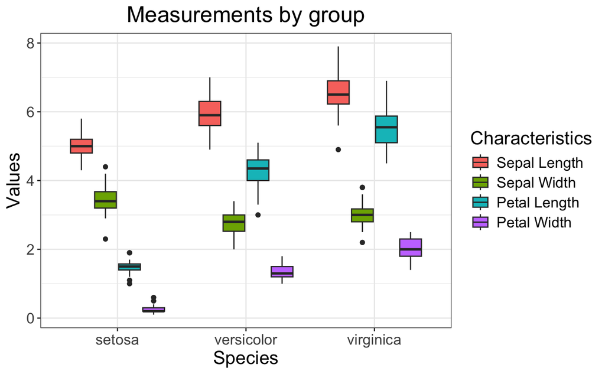

After which, let us look into the relationship of each of these variables so we will see whether they are clustered altogether or if it’s a different case per species. This will help us understand whether the variables can be predictable per species. Let’s see whether PCA or t-SNE is more applicable. However, I do believe that PCA is more applicable as I am handling a 1-D data instead of 2D data but let us see in practice.

```r
## PCA
#PCA
install.packages("factoextra")
library(factoextra)
iris.data <- iris[,1:4]
iris.name < iris[,5]
system.time(p <- prcomp(iris.data, scale=TRUE)) # user:0.001 system:0.001 elapsed: 0.005
names(p)
summary(p)

# Plot PCA with labels
fviz_pca_ind(p,
             geom.ind = "point", # Show points only (no text)
             col.ind = iris.name, # Color by species
             addEllipses = FALSE, # Add concentration ellipses
             legend.title = "Species") +
  theme_minimal() +
  labs(title = "PCA of Iris Dataset", center=TRUE,
       x = "PC1",
       y = "PC2") +
  theme(plot.title = element_text(hjust = 0.5)) # Center the title
```

[output not shown]

And here is for the tSNE

```r
# t-SNE
set.seed(1)
library(Rtsne)
iris_d_tsne <- as.matrix(iris[,1:4])
system.time(iris.rtsne <- Rtsne(iris_d_tsne, check_duplicates = FALSE, verbose = F)) # user: 0.321 system:0.00 elapsed:0.322

# plot
# Create a data frame for the t-SNE results
tsne_df <- data.frame(iris.rtsne$Y, Species = iris$Species)
colnames(tsne_df) <- c("tSNE1", "tSNE2", "Species")

# Plot t-SNE results
ggplot(tsne_df, aes(x = tSNE1, y = tSNE2, color = Species)) +
  geom_point(size = 2) +
  theme_minimal() +
  labs(title = "t-SNE of Iris Dataset",
       x = "t-SNE Dimension 1",
       y = "t-SNE Dimension 2") +
  theme(plot.title = element_text(hjust = 0.5)) # Center the title
```

[output not shown]